# Linear Algebra

빅데이터분석실무 4주차

ssongplay

2021-10-26

# 벡터끼리의 덧셈

```r
# 벡터끼리의 덧셈
X = c(1, 3, 5)
Y = c(2, -1, 0)
X + Y
```

```
## [1] 3 2 5
```

### 벡터끼리의 덧셈 : 시각화 in R* (matlib library)

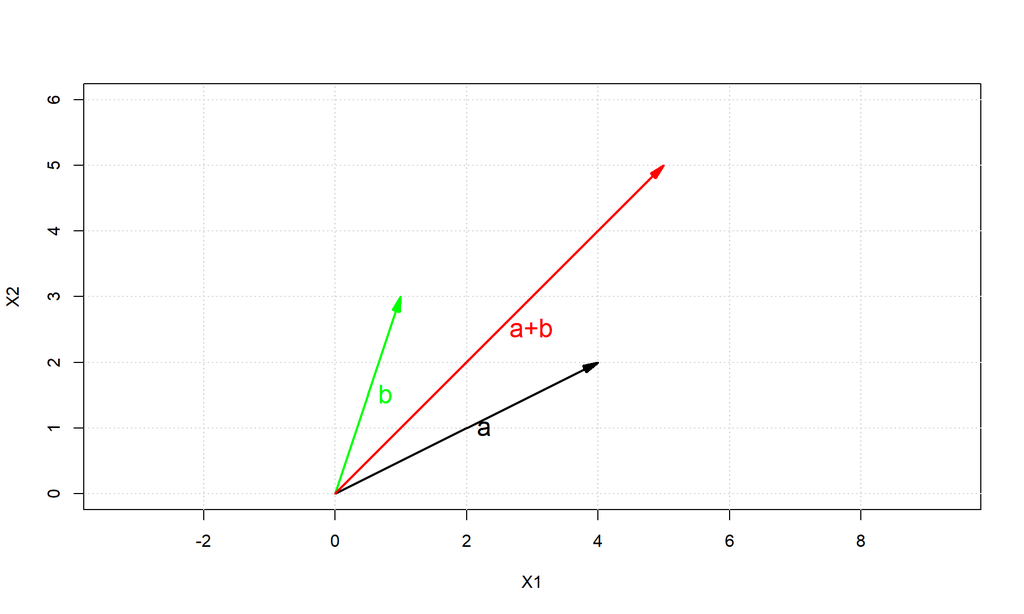

```r
library(matlib)  # matlib library setting

# 플롯 기본 셋팅
xlim <- c(0,6)
ylim <- c(0,6)
plot(xlim, ylim, type="n", xlab="X1", ylab="X2", asp=1)
grid()

# define some vectors
a = c(4,2)
b = c(1,3)

# vector plotting (vectors 함수 활용)
vectors(b, labels="b", pos.lab=4, frac.lab=.5, col="green")
vectors(a, labels="a", pos.lab=4, frac.lab=.5)
vectors(a+b, labels="a+b", pos.lab=4, frac.lab=.5, col="red")
```

# 벡터의 길이 (피타고라스의 정리)

```r
# x가 (3,5), y가 (1,2)일때 빗변의 길이
x = c(3, 5)
y = c(1, 2)
y_x = sqrt((3-1)^2 + (5-2)^2)
y_x
```

```
## [1] 3.605551
```

# 벡터의 각

- 벡터의 각은 곧, 두 벡터간의 관계를 의미!
- 만약 A벡터와 B 벡터가 이루는 각이 90° ? 270° ? > 서로 독립적인 벡터
- 반대로 이루는 각이 0° ? 180° ? > 서로 관계가 깊은 벡터
- 그래서 cos θ를 통해 벡터간의 관계를 파악 가능!!
- Let’s try a(0,4), b(5,0) ? a & b 두 벡터의 각은 ?

```r
a = c(0,4)
b = c(5,0)
a%*%b/(sqrt(a%*%a) %*% sqrt(b%*%b))
```

```
##      [,1]
## [1,]    0
```

# 벡터의 내적 (inner product)

- 내적의 정의
- $$\vec{a} \, \cdot\, \vec{b} = |\vec{a}|*|\vec{b}|*\cos\theta$$
- 즉, 두 벡터의 크기 (norm)와 이루는 각의 코사인 곱을 통한 연산
- 벡터와 벡터의 곱이지만 값은 실수(스칼라) 하나로 나옴
- 각의 주는 의미와 마찬가지로 결국 두 벡터의 연관성을 표현 (그래서 다변량으로 표현되는 머신러닝/데이터분석의 세계에서 매우 중요)

```r
a = c(2,4)
b = c(3,1)
cos_theta = a%*%b/(sqrt(a%*%a) %*% sqrt(b%*%b))
length_a = sqrt(2^2 + 4^2)
length_b = sqrt(3^2 + 1^2)
length_a * length_b * cos_theta
```

```
##      [,1]
## [1,]   10
```

- 내적의 선형대수 정의
- $$a^{T}b$$

### cosine 함수 그려보기

- $$\cos\theta=0.7일때 \theta는?$$

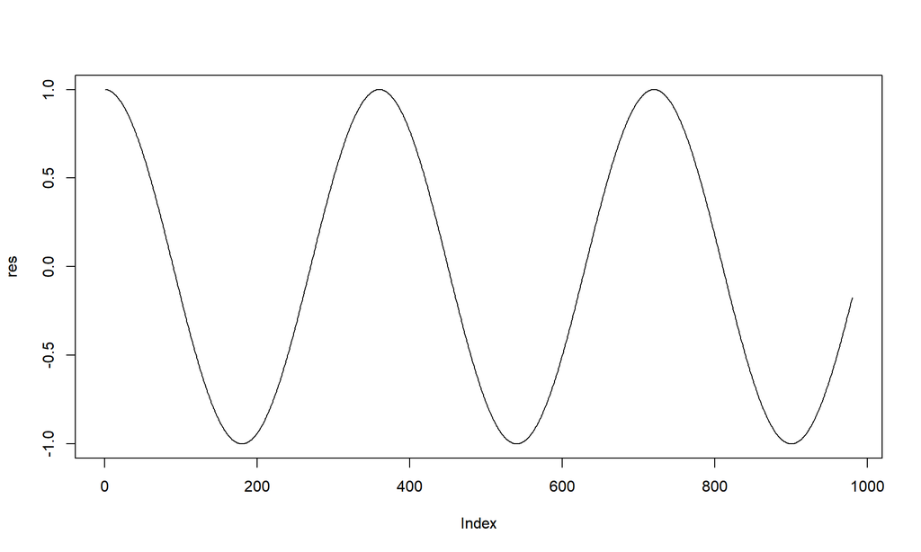

```r
res = matrix(0, 980, 1)  # 결과 저장
for(i in 1:980){ # 각도를 키워가며 코사인 값 계산
  res[i,1] = cos(i*pi/180) # 수치를 각도로 변환
}
plot(res, type = "l")
```

```r
which(res <= 0.7)  # 0.7보다 처음으로 작아지는 값?
```

```
##   [1]  46  47  48  49  50  51  52  53  54  55  56  57  58  59  60  61  62  63
##  [19]  64  65  66  67  68  69  70  71  72  73  74  75  76  77  78  79  80  81
##  [37]  82  83  84  85  86  87  88  89  90  91  92  93  94  95  96  97  98  99
##  [55] 100 101 102 103 104 105 106 107 108 109 110 111 112 113 114 115 116 117
##  [73] 118 119 120 121 122 123 124 125 126 127 128 129 130 131 132 133 134 135
##  [91] 136 137 138 139 140 141 142 143 144 145 146 147 148 149 150 151 152 153
## [109] 154 155 156 157 158 159 160 161 162 163 164 165 166 167 168 169 170 171
## [127] 172 173 174 175 176 177 178 179 180 181 182 183 184 185 186 187 188 189
## [145] 190 191 192 193 194 195 196 197 198 199 200 201 202 203 204 205 206 207
## [163] 208 209 210 211 212 213 214 215 216 217 218 219 220 221 222 223 224 225
## [181] 226 227 228 229 230 231 232 233 234 235 236 237 238 239 240 241 242 243
## [199] 244 245 246 247 248 249 250 251 252 253 254 255 256 257 258 259 260 261
## [217] 262 263 264 265 266 267 268 269 270 271 272 273 274 275 276 277 278 279
## [235] 280 281 282 283 284 285 286 287 288 289 290 291 292 293 294 295 296 297
## [253] 298 299 300 301 302 303 304 305 306 307 308 309 310 311 312 313 314 406
```

[output cut: 27 more lines]

# Transpose

```r
a = matrix(c(2,0,1,1,3,-1), nrow=2)
a
```

```
##      [,1] [,2] [,3]
## [1,]    2    1    3
## [2,]    0    1   -1
```

```r
a_t = t(a)
a_t
```

```
##      [,1] [,2]
## [1,]    2    0
## [2,]    1    1
## [3,]    3   -1
```

# 행렬간 합

```r
a = matrix(c(1, 4, 2, 5, 3, 6), nrow = 2)
a
```

```
##      [,1] [,2] [,3]
## [1,]    1    2    3
## [2,]    4    5    6
```

```r
b = matrix(c(0, 2, 1, -1, 0, 5), nrow = 2)
b
```

```
##      [,1] [,2] [,3]
## [1,]    0    1    0
## [2,]    2   -1    5
```

```r
mat_sum = a + b
mat_sum
```

```
##      [,1] [,2] [,3]
## [1,]    1    3    3
## [2,]    6    4   11
```

# 행렬에 스칼라 곱

```r
c1 = 2
A = matrix(c(1, 2, 0, 5), nrow=2)
c1 * A
```

```
##      [,1] [,2]
## [1,]    2    0
## [2,]    4   10
```

# 행렬끼리의 곱

```r
A = matrix(c(3, 4, -1, 0, 2, 5), nrow = 2)
B = matrix(c(3, 6, 4, 4, -2, 3), nrow = 3)
C = A %*% B
C
```

```
##      [,1] [,2]
## [1,]   11   20
## [2,]   32   31
```

# Determinant

- Volume of a matrix
- 역행렬의 존재를 확인하는 도구로써 활용 (1/det(A))

```r
A = matrix(c(1, 6, 3, 4), nrow = 2)
det(A)
```

```
## [1] -14
```

```r
B = matrix(c(3, 7, 2, 1, 4, -7, 6, 5, 1), nrow = 3)
det(B)
```

```
## [1] -222
```

# Inverse

- 숫자의 세계에는 역수라는 개념 존재 (분모와 분자가 뒤집힌 형태)
- 역수는 어떤 숫자가 곱했을 때 , 자기자신(즉, 항등원)인 1이 나오게하는 수
- 행렬에는 역행렬이 그런 역할을 해줌. 즉 나누기의 역할을 위한 행렬이라고 보면 됨
- 행렬의 항등원은 바로 I (Identity matrix, 대각행렬이 1로만 채워진 행렬)
- 가장 대표적인 활용 : linear equation
- AX = Y라는 문제를 X = A^-1 Y 형태로 변환하여 쉽게 X를 구할 수 있다
- R 에서는 `solve` 함수를 활용. 혹은 pracma 라이브러리의 `Inv()` 함수

```r
mat = matrix(c(2, 4, 3, 1, 3, 2, 4, 5, 1, 2, 3, 4, 1, 1, 2, 4), nrow = 4)
mat
```

```
##      [,1] [,2] [,3] [,4]
## [1,]    2    3    1    1
## [2,]    4    2    2    1
## [3,]    3    4    3    2
## [4,]    1    5    4    4
```

```r
solve(mat)
```

```
##            [,1] [,2] [,3]        [,4]
## [1,]  0.2142857  0.5 -0.5  0.07142857
## [2,]  0.3571429 -0.5  0.5 -0.21428571
## [3,] -1.0714286 -0.5  1.5 -0.35714286
## [4,]  0.5714286  1.0 -2.0  0.85714286
```

```r
library("pracma")
inv(mat)
```

```
##            [,1] [,2] [,3]        [,4]
## [1,]  0.2142857  0.5 -0.5  0.07142857
## [2,]  0.3571429 -0.5  0.5 -0.21428571
## [3,] -1.0714286 -0.5  1.5 -0.35714286
## [4,]  0.5714286  1.0 -2.0  0.85714286
```

```r
mat %*% inv(mat)
```

```
##              [,1] [,2] [,3]          [,4]
## [1,] 1.000000e+00    0    0 -1.110223e-16
## [2,] 1.110223e-16    1    0  0.000000e+00
## [3,] 2.220446e-16    0    1  0.000000e+00
## [4,] 0.000000e+00    0    0  1.000000e+00
```

# Trace (대각 행렬 원소들의 합)

```r
A = matrix(c(1, 3, 2, 4), nrow=2)
A_T = t(A)
sum(diag(A%*%A_T))
```

```
## [1] 30
```

# Vector의 norm

- “거리”
- 벡터 혹은 행렬의 크기를 표현하는 단위
- R에서는 `pracma` package의 `Norm()` 함수를 통해 사용
- 벡터나 매트릭스의 크기나 강도, 대표값 등을 알기 어렵기 때문에 하나의 값으로 정의해서 파악하기 위함

```r
v = c(1, 2, 1)
v
```

```
## [1] 1 2 1
```

```r
Norm(v, p=2)
```

```
## [1] 2.44949
```

```r
P = matrix(c(2, 4, 3, 2), ncol=2)
P
```

```
##      [,1] [,2]
## [1,]    2    3
## [2,]    4    2
```

```r
Norm(P, p=1)
```

```
## [1] 11
```

# Eigenvalue & Eigenvector

- 고유값과 고유벡터
- Eigenvector : A를 선형변환 했을 때, 변환결과가 자기 자신의 상수배가 되는 0이 아닌 벡터
- Eigenvalue : 상수배값
- $$Av = \lambda v$$
- $$A = v \lambda\ v^{-1}$$
  로 표현하면 행렬 A는 자신의 고유벡터들을 열벡터로 하는 행렬과 고유값을 대각원소로 하는 행렬의 곱으로 분해가 가능 –> “고유값 분해”
- 고유값 분해로 행렬의 다양한 연산을 손쉽게 계산 가능
- Trace(A) = λ1+ λ2+ λ3……
- PCA(주성분분석) : eigenvalue decomposition을 활용하여 데이터를 효과적으로 축약해주는 방식
- 특성화 방정식 det(A- λI)
- A- λI = 0 : 고유벡터 존재 조건
- R에서 `eigen` 함수를 이용하여 구함

```r
mat = matrix(c(5, 25, 35, 25, 166, 175, 35, 175, 325), ncol = 3)
mat
```

```
##      [,1] [,2] [,3]
## [1,]    5   25   35
## [2,]   25  166  175
## [3,]   35  175  325
```

```r
eanalysis = eigen(mat, symmetric = T)  # mat가 대칭 행렬인지 test
eanalysis
```

```
## eigen() decomposition
## $values
## [1] 441.9358385  53.3688218   0.6953397
##
## $vectors
##             [,1]        [,2]        [,3]
## [1,] -0.09785612 -0.03883037  0.99444275
## [2,] -0.53931478 -0.83772380 -0.08578109
## [3,] -0.83639928  0.54471188 -0.06103460
```